# Unsupervised_Learning_Project_Samir_Karandikar_R1

### Method "Average' gave us the best Cophenetic Coefficient so we use linkage matrix Z1 for the remaining work

```python
Z1[639:]
```

```
array([[1.22800000e+03, 1.29600000e+03, 1.42115296e+00, 1.08000000e+02],
       [1.28800000e+03, 1.29200000e+03, 1.42764430e+00, 1.02000000e+02],
       [1.26500000e+03, 1.28900000e+03, 1.46027507e+00, 8.00000000e+00],
       [1.28300000e+03, 1.29300000e+03, 1.48514030e+00, 7.00000000e+01],
       [1.27600000e+03, 1.27800000e+03, 1.50823619e+00, 1.20000000e+01],
       [1.29100000e+03, 1.29800000e+03, 1.55775899e+00, 2.00000000e+01],
       [1.29500000e+03, 1.30000000e+03, 1.57762381e+00, 1.93000000e+02],
       [1.29700000e+03, 1.30200000e+03, 1.61398386e+00, 1.93000000e+02],
       [1.29400000e+03, 1.29900000e+03, 1.63321449e+00, 2.20000000e+02],
       [1.26400000e+03, 1.28400000e+03, 1.65653632e+00, 8.00000000e+00],
       [1.30500000e+03, 1.30600000e+03, 1.82879539e+00, 3.86000000e+02],
       [1.30300000e+03, 1.30400000e+03, 2.03498289e+00, 3.20000000e+01],
       [1.30100000e+03, 1.30800000e+03, 2.04982728e+00, 1.60000000e+01],
       [1.16200000e+03, 1.30700000e+03, 2.29454005e+00, 2.22000000e+02],
       [1.31000000e+03, 1.31100000e+03, 2.38705570e+00, 4.80000000e+01],
       [1.13700000e+03, 1.31300000e+03, 2.50280165e+00, 5.00000000e+01],
       [1.00000000e+00, 1.31200000e+03, 2.79420150e+00, 2.23000000e+02],
       [0.00000000e+00, 1.30900000e+03, 3.11135778e+00, 3.87000000e+02],
       [1.31500000e+03, 1.31600000e+03, 3.25253923e+00, 6.10000000e+02],
       [1.31400000e+03, 1.31700000e+03, 5.45418035e+00, 6.60000000e+02]])
```

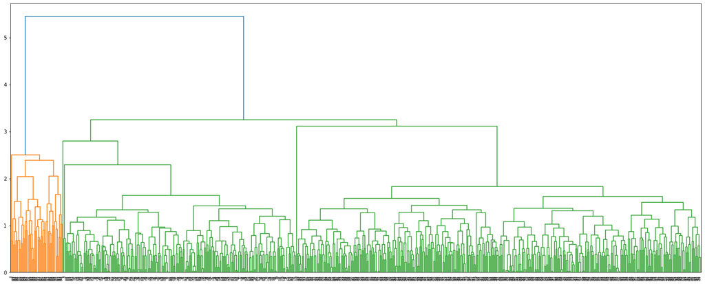

```python
#Plots Dendrogram for the consolidated Dataframe
#
plt.figure(figsize=(25, 10))
dendrogram(Z1)
plt.show()
```

```python
max_d = 3.15
from scipy.cluster.hierarchy import fcluster
clusters = fcluster(Z1, max_d, criterion='distance')
print(clusters.shape)
clusters
```

```
(660,)
```

```
array([3, 2, 3, 3, 1, 2, 1, 2, 2, 2, 2, 2, 2, 2, 2, 2, 2, 2, 2, 2, 2, 2,
       2, 2, 2, 2, 2, 2, 2, 2, 2, 2, 2, 2, 2, 2, 2, 2, 2, 2, 2, 2, 2, 2,
       2, 2, 2, 2, 2, 2, 2, 2, 2, 2, 2, 2, 2, 2, 2, 2, 2, 2, 2, 2, 2, 2,
       2, 2, 2, 2, 2, 2, 2, 2, 2, 2, 2, 2, 2, 2, 2, 2, 2, 2, 2, 2, 2, 2,
       2, 2, 2, 2, 2, 2, 2, 2, 2, 2, 2, 2, 2, 2, 2, 2, 2, 2, 2, 2, 2, 2,
       2, 2, 2, 2, 2, 2, 2, 2, 2, 2, 2, 2, 2, 2, 2, 2, 2, 2, 2, 2, 2, 2,
       2, 2, 2, 2, 2, 2, 2, 2, 2, 2, 2, 2, 2, 2, 2, 2, 2, 2, 2, 2, 2, 2,
       2, 2, 2, 2, 2, 2, 2, 2, 2, 2, 2, 2, 2, 2, 2, 2, 2, 2, 2, 2, 2, 2,
       2, 2, 2, 2, 2, 2, 2, 2, 2, 2, 2, 2, 2, 2, 2, 2, 2, 2, 2, 2, 2, 2,
       2, 2, 2, 2, 2, 2, 2, 2, 2, 2, 2, 2, 2, 2, 2, 2, 2, 2, 2, 2, 2, 2,
       2, 2, 2, 2, 2, 2, 2, 2, 3, 3, 3, 3, 3, 3, 3, 3, 3, 3, 3, 3, 3, 3,
       3, 3, 3, 3, 3, 3, 3, 3, 3, 3, 3, 3, 3, 3, 3, 3, 3, 3, 3, 3, 3, 3,
       3, 3, 3, 3, 3, 3, 3, 3, 3, 3, 3, 3, 3, 3, 3, 3, 3, 3, 3, 3, 3, 3,
       3, 3, 3, 3, 3, 3, 3, 3, 3, 3, 3, 3, 3, 3, 3, 3, 3, 3, 3, 3, 3, 3,
       3, 3, 3, 3, 3, 3, 3, 3, 3, 3, 3, 3, 3, 3, 3, 3, 3, 3, 3, 3, 3, 3,
```

[output cut: 16 more lines]

```python
Data_df["labels"] = clusters
X_std["labels"] = clusters
Data_df_features["labels"] = clusters
```

```python
Data_df_features["Group"] = prediction
```

[output not shown]

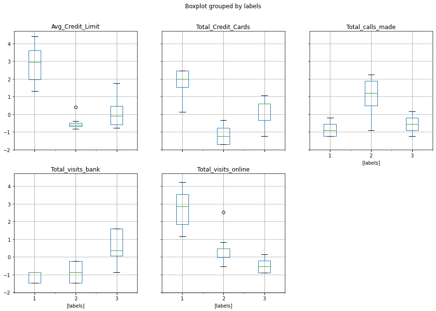

```python
# This code creates the boxplot of the labels created by Hierarchical Clustering
X_std.boxplot(by='labels', layout = (2,3),figsize=(15,10))
```

## 5. Average Silhoutte Score

```
Calculate average silhouette score for both methods. (5 marks)
```

```python
from sklearn.metrics import silhouette_samples,silhouette_score
```

```python
centroids  = second_model.cluster_centers_
```

```python
Data_scaled2 = Data_scaled.drop("Group", axis =1)
# get silhouette
silhouette_vals = silhouette_samples(Data_scaled2,prediction)
    #silhouette_vals
    #
# Calculate Silhoutte Score
# Silhoutte score between 0 and 1 is a good score with the score closer to 1 being better
score = silhouette_score(Data_scaled2, second_model.labels_, metric='euclidean')
```

```python
print('KMeans Model K=3, Silhouette Score: %.6f' % score)
```

```
KMeans Model K=3, Silhouette Score: 0.515718
```

```python
# Calculate Silhoutter Score for Hierarchical Model
Data_scaled4 = X_std.drop("labels", axis =1)
# get silhouette
silhouette_vals = silhouette_samples(Data_scaled4,clusters)
    #silhouette_vals
    #
# Calculate Silhoutte Score
#
score2 = silhouette_score(Data_scaled4, clusters, metric='euclidean')
print('Hierarchical Model, Silhouette Score: %.6f' % score2)
```

```
Hierarchical Model, Silhouette Score: 0.515922
```

## Hierarchical Model provides slightly higher Silhoutte score than KMeans Model

## 6. Comparison between K-Means clusters and Hierarchical Cluster

Compare K-means clusters with Hierarchical clusters. (5 marks)

```python
Data_df.head(20)
```

|  | Sl_No | Customer Key | Avg_Credit_Limit | Total_Credit_Cards | Total_visits_bank | Total_visits_online | Total_calls_made | Group | labels |
| --- | --- | --- | --- | --- | --- | --- | --- | --- | --- |
| 0 | 1 | 87073 | 100000 | 2 | 1 | 1 | 0 | 0 | 3 |
| 1 | 2 | 38414 | 50000 | 3 | 0 | 10 | 9 | 1 | 2 |
| 2 | 3 | 17341 | 50000 | 7 | 1 | 3 | 4 | 0 | 3 |
| 3 | 4 | 40496 | 30000 | 5 | 1 | 1 | 4 | 0 | 3 |
| 4 | 5 | 47437 | 100000 | 6 | 0 | 12 | 3 | 2 | 1 |
| 5 | 6 | 58634 | 20000 | 3 | 0 | 1 | 8 | 1 | 2 |
| 6 | 7 | 48370 | 100000 | 5 | 0 | 11 | 2 | 2 | 1 |
| 7 | 8 | 37376 | 15000 | 3 | 0 | 1 | 1 | 1 | 2 |
| 8 | 9 | 82490 | 5000 | 2 | 0 | 2 | 2 | 1 | 2 |
| 9 | 10 | 44770 | 3000 | 4 | 0 | 1 | 7 | 1 | 2 |
| 10 | 11 | 52741 | 10000 | 4 | 0 | 5 | 5 | 1 | 2 |
| 11 | 12 | 52326 | 13000 | 3 | 0 | 2 | 7 | 1 | 2 |
| 12 | 13 | 92503 | 11000 | 1 | 2 | 5 | 9 | 1 | 2 |
| 13 | 14 | 25084 | 9000 | 1 | 1 | 5 | 6 | 1 | 2 |
| 14 | 15 | 68517 | 6000 | 2 | 2 | 4 | 6 | 1 | 2 |
| 15 | 16 | 55196 | 8000 | 2 | 0 | 5 | 7 | 1 | 2 |
| 16 | 17 | 62617 | 15000 | 2 | 1 | 2 | 4 | 1 | 2 |
| 17 | 18 | 96463 | 8000 | 2 | 0 | 3 | 4 | 1 | 2 |
| 18 | 19 | 39137 | 11000 | 2 | 2 | 2 | 7 | 1 | 2 |
| 19 | 20 | 14309 | 19000 | 4 | 1 | 5 | 8 | 1 | 2 |

```python
#There appears to be a good equivalence between KMeans Group and Hierarchical Clustering labels
# Group 0 ~ label 3
# Group 1 ~ label 2
# Group 2 ~ label 1
i=0
match_g0_l3 = 0
No_match_g0_l3 = 0
match_g1_l2 = 0
No_match_g1_l2 = 0
match_g2_l1 = 0
No_match_g2_l1 = 0

# We run a loop for loop through Dataframe Data_df which has Group and labels definition
# A comparison is made of the equivalent clusters in order to draw conclusions.
#
for i in range(len(Data_df)):
    if Data_df['Group'][i]==0 and Data_df['labels'][i]==3:
        match_g0_l3 = match_g0_l3 +1
    else:
        if Data_df['Group'][i]==1 and Data_df['labels'][i]==2:
            match_g1_l2 = match_g1_l2 +1
        else:
            if Data_df['Group'][i]==2 and Data_df['labels'][i]==1:
                match_g2_l1 = match_g2_l1 +1
    if Data_df['Group'][i]==0 and Data_df['labels'][i]!=3:
        No_match_g0_l3 = No_match_g0_l3+1
    if Data_df['Group'][i]==1 and Data_df['labels'][i]!=2:
        No_match_g1_l2 = No_match_g1_l2+1
    if ((Data_df['Group'][i]==2)&(Data_df['labels'][i]!=1)):
        No_match_g2_l1 = No_match_g2_l1+1
    i=i+1
print( 'Group 0 matches with label 3:', match_g0_l3)
print('Group 1 matches with label 2: ', match_g1_l2 )
print('Group 2 matches with label 1:', match_g2_l1, '\n')
print('No match between Group 0 and label 3:', No_match_g0_l3)
print("Percentage of total = "+"{0:.4f}%".format(No_match_g0_l3/6.6))
print('No match between Group 1 and label 2:', No_match_g1_l2)
print("Percentage of total = "+"{0:.4f}%".format(No_match_g1_l2/6.6))
print('No match between Group 2 and label 1:', No_match_g2_l1)
print("Percentage of total = "+"{0:.4f}%".format(No_match_g2_l1/6.6))
```

```
Group 0 matches with label 3: 386
Group 1 matches with label 2:  223
Group 2 matches with label 1: 50

No match between Group 0 and label 3: 0
Percentage of total = 0.0000%
No match between Group 1 and label 2: 1
Percentage of total = 0.1515%
No match between Group 2 and label 1: 0
Percentage of total = 0.0000%
```

### When KMeans Clusters and Hierarchical Clusters are compared there is equivalence in 659 out of 660 records.

### There is only record which is assigned Group 1 by KMeans but does not get assigned equivalent label 2 by Hierarchical Clustering program.

```python
writer = pd.ExcelWriter('output.xlsx')
# write dataframe to excel to study the data independently
Data_df.to_excel(writer)
# save to excel
writer.save()
```

## 7. Analysis of the clusters formed

```
Tell us how is one cluster different from another and answer all the key questions. (10 marks)
```

```python
HierDataClust = Data_df.groupby(['labels'])
HierDataClust.mean()
```

| labels | Sl_No | Customer Key | Avg_Credit_Limit | Total_Credit_Cards | Total_visits_bank | Total_visits_online | Total_calls_made | Group |
| --- | --- | --- | --- | --- | --- | --- | --- | --- |
| 1 | 611.280000 | 56708.760000 | 141040.000000 | 8.740000 | 0.600000 | 10.900000 | 1.080000 | 2.000000 |
| 2 | 116.977578 | 55163.973094 | 12197.309417 | 2.403587 | 0.928251 | 3.560538 | 6.883408 | 1.000000 |
| 3 | 417.260982 | 54925.966408 | 33713.178295 | 5.511628 | 3.485788 | 0.984496 | 2.005168 | 0.002584 |

```python
DataClust.describe().T
```

|  | Group | 0 | 1 | 2 |
| --- | --- | --- | --- | --- |
| Avg_Credit_Limit | count | 386.000000 | 224.000000 | 50.000000 |
|  | mean | 33782.383420 | 12174.107143 | 141040.000000 |
|  | std | 22169.460696 | 5249.048524 | 34457.877272 |
|  | min | 5000.000000 | 3000.000000 | 84000.000000 |
|  | 25% | 13000.000000 | 8000.000000 | 108750.000000 |
|  | 50% | 31000.000000 | 12000.000000 | 145500.000000 |
|  | 75% | 52000.000000 | 16000.000000 | 170000.000000 |
|  | max | 100000.000000 | 50000.000000 | 200000.000000 |
| Total_Credit_Cards | count | 386.000000 | 224.000000 | 50.000000 |
|  | mean | 5.515544 | 2.410714 | 8.740000 |
|  | std | 1.140069 | 1.100783 | 1.274715 |
|  | min | 2.000000 | 1.000000 | 5.000000 |
|  | 25% | 4.000000 | 1.000000 | 8.000000 |
|  | 50% | 6.000000 | 2.000000 | 9.000000 |
|  | 75% | 6.000000 | 3.000000 | 10.000000 |
|  | max | 7.000000 | 4.000000 | 10.000000 |
| Total_visits_bank | count | 386.000000 | 224.000000 | 50.000000 |
|  | mean | 3.489637 | 0.933036 | 0.600000 |
|  | std | 1.135563 | 0.803567 | 0.494872 |
|  | min | 1.000000 | 0.000000 | 0.000000 |
|  | 25% | 3.000000 | 0.000000 | 0.000000 |
|  | 50% | 3.000000 | 1.000000 | 1.000000 |
|  | 75% | 5.000000 | 2.000000 | 1.000000 |
|  | max | 5.000000 | 2.000000 | 1.000000 |
| Total_visits_online | count | 386.000000 | 224.000000 | 50.000000 |
|  | mean | 0.981865 | 3.553571 | 10.900000 |
|  | std | 0.857167 | 1.218978 | 2.880264 |
|  | min | 0.000000 | 1.000000 | 6.000000 |
|  | 25% | 0.000000 | 2.000000 | 8.000000 |
|  | 50% | 1.000000 | 4.000000 | 11.000000 |
|  | 75% | 2.000000 | 4.000000 | 13.000000 |
|  | max | 3.000000 | 10.000000 | 15.000000 |
| Total_calls_made | count | 386.000000 | 224.000000 | 50.000000 |
|  | mean | 2.000000 | 6.870536 | 1.080000 |
|  | std | 1.430648 | 1.990161 | 0.876915 |
|  | min | 0.000000 | 1.000000 | 0.000000 |
|  | 25% | 1.000000 | 5.000000 | 0.000000 |
|  | 50% | 2.000000 | 7.000000 | 1.000000 |
|  | 75% | 3.000000 | 9.000000 | 2.000000 |
|  | max | 4.000000 | 10.000000 | 3.000000 |
| labels | count | 386.000000 | 224.000000 | 50.000000 |
|  | mean | 3.000000 | 2.004464 | 1.000000 |
|  | std | 0.000000 | 0.066815 | 0.000000 |
|  | min | 3.000000 | 2.000000 | 1.000000 |
|  | 25% | 3.000000 | 2.000000 | 1.000000 |
|  | 50% | 3.000000 | 2.000000 | 1.000000 |
|  | 75% | 3.000000 | 2.000000 | 1.000000 |
|  | max | 3.000000 | 3.000000 | 1.000000 |

### Group 0 and Lable 3: 386 Customers

This is the largest cluster of customers. This cluster is made of middle range of average credit limit (range 5k-100k, mean = 33.8k), medium number of credit cards (range 2-7, mean=5.5) and high visits to bank (1-5, mean = 3.5). This cluster has the lowest total online visits (range 0-3, mean = 0.98) and low calls made (range 0-4, mean = 2). The appropriate method to catch these customers is by person to person contact in the bank during their visit.

### Group 2 and Label 1 : 50 Customers

This is the smallest cluster and it is made of the highest average credit limit (range 84k-200k, mean =141k), high number of total credit cards(5-10, mean of 8.74), and high on-line visits (6-15 visits, mean of 10.9). This cluster has lower total bank visits (0-1 with mean of 0.6) and total calls (0-3 with mean of 1.08). The appropriate method to catch their attention would be through Online advertising.

### There is customer SI No 314 who is Group 1 but Hierarchical Clustering has assigned this customer to Label 3, instead of equivalent Label 2

## Answers to key questions-

### 1. How many different segments of customers are there?

There are three (3) segments of customers.

### 2. How are these segments different from each other?

As described in the paragraph above the three segments are characterized by features-

The first cluster (Label 1 or Group 2) with highest average credit limit and number of credit cards seems to be using on-line method to contact bank.

The next cluster (Label 3 or Group 0) with medium credit limit is the largest and would be the appropriate cluster to increase penetration.

The third cluster (Label 2 or Group 1) is the lowest credit limit group and they don't have many credit cards.

### 3. What are your recommendations to the bank on how to better market to and service these customers?

Label 1 or Group 2 - It would be important to improve the on-line support services to please these customers.

Label 2 or Group 1 - This group could be marketed for signing up for credit cards via phone calls. This group prefers making phone calls.

Label 3 or Group 0 - This cluster makes maximum visits to the bank and that would be the most appropriate area to support these customers.